# Stat6000 Project

```r
library(ggplot2)
library(caret)
library(tidyverse)
library(ISLR)
library(randomForest)
library(class)
library(e1071)
library(MASS)
library(caTools)
```

#Get Data Ready

First we need to read in our data set

```r
#below is one way to read in the data
#winequality.red <- read.csv("~/GitHub/STAT6000Project/winequality-red.csv", sep=";")

#This is another way to read in the data and the one that
#we will use for the project
winequality.red<-read.csv("winequality-red.csv",sep = ";")
head(winequality.red)
```

```
##   fixed.acidity volatile.acidity citric.acid residual.sugar chlorides
## 1           7.4             0.70        0.00            1.9     0.076
## 2           7.8             0.88        0.00            2.6     0.098
## 3           7.8             0.76        0.04            2.3     0.092
## 4          11.2             0.28        0.56            1.9     0.075
## 5           7.4             0.70        0.00            1.9     0.076
## 6           7.4             0.66        0.00            1.8     0.075
##   free.sulfur.dioxide total.sulfur.dioxide density   pH sulphates alcohol
## 1                  11                   34  0.9978 3.51      0.56     9.4
## 2                  25                   67  0.9968 3.20      0.68     9.8
## 3                  15                   54  0.9970 3.26      0.65     9.8
## 4                  17                   60  0.9980 3.16      0.58     9.8
## 5                  11                   34  0.9978 3.51      0.56     9.4
## 6                  13                   40  0.9978 3.51      0.56     9.4
##   quality
## 1       5
## 2       5
## 3       5
## 4       6
## 5       5
## 6       5
```

Now we need to make sure there are no empty values or missing values

```r
summary(complete.cases(winequality.red))
```

```
##    Mode    TRUE
## logical    1599
```

Doing this check shows us that we do not have any missing values in our data set. Now lets do some summary statistics and plots of the response value of quality.

```r
summary(winequality.red)
```

```
##  fixed.acidity   volatile.acidity  citric.acid    residual.sugar
##  Min.   : 4.60   Min.   :0.1200   Min.   :0.000   Min.   : 0.900
##  1st Qu.: 7.10   1st Qu.:0.3900   1st Qu.:0.090   1st Qu.: 1.900
##  Median : 7.90   Median :0.5200   Median :0.260   Median : 2.200
##  Mean   : 8.32   Mean   :0.5278   Mean   :0.271   Mean   : 2.539
##  3rd Qu.: 9.20   3rd Qu.:0.6400   3rd Qu.:0.420   3rd Qu.: 2.600
##  Max.   :15.90   Max.   :1.5800   Max.   :1.000   Max.   :15.500
##    chlorides       free.sulfur.dioxide total.sulfur.dioxide    density
##  Min.   :0.01200   Min.   : 1.00       Min.   :  6.00       Min.   :0.9901
##  1st Qu.:0.07000   1st Qu.: 7.00       1st Qu.: 22.00       1st Qu.:0.9956
##  Median :0.07900   Median :14.00       Median : 38.00       Median :0.9968
##  Mean   :0.08747   Mean   :15.87       Mean   : 46.47       Mean   :0.9967
##  3rd Qu.:0.09000   3rd Qu.:21.00       3rd Qu.: 62.00       3rd Qu.:0.9978
##  Max.   :0.61100   Max.   :72.00       Max.   :289.00       Max.   :1.0037
##        pH          sulphates         alcohol         quality
##  Min.   :2.740   Min.   :0.3300   Min.   : 8.40   Min.   :3.000
##  1st Qu.:3.210   1st Qu.:0.5500   1st Qu.: 9.50   1st Qu.:5.000
##  Median :3.310   Median :0.6200   Median :10.20   Median :6.000
##  Mean   :3.311   Mean   :0.6581   Mean   :10.42   Mean   :5.636
##  3rd Qu.:3.400   3rd Qu.:0.7300   3rd Qu.:11.10   3rd Qu.:6.000
##  Max.   :4.010   Max.   :2.0000   Max.   :14.90   Max.   :8.000
```

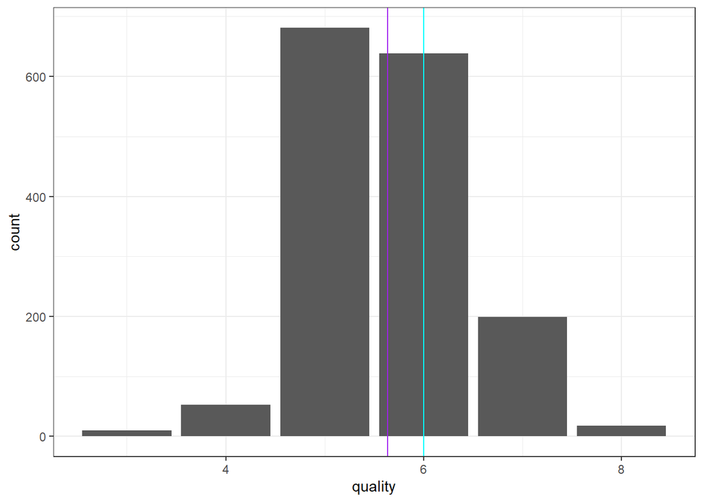

```r
#bar graph of the data
ggplot(data = winequality.red) +
  geom_bar(mapping = aes(x = quality))+
  geom_vline(xintercept=mean(winequality.red$quality), color="purple")+
  geom_vline(xintercept=median(winequality.red$quality), color="cyan")+theme_bw()
```

From the data page, it points out that the wine is good if its quality is larger than 6.5, then we create a new factor variable which will be used for our model response, if `quality` is bigger than 6.5, it is equal to 1, otherwise, it is 0. Moreover, we notice that the number of “bad” red wine is much more than the “good” ones, and it might influence our experiment.

```r
winequality.red$Quality <- rep(0,dim(winequality.red)[1])
winequality.red$Quality[winequality.red$quality>6.5] <- "1"
winequality.red$Quality <- as.factor(winequality.red$Quality)
wine<-winequality.red[,c(1:11,13)] ###dataset for below steps###
head(wine)
```

```
##   fixed.acidity volatile.acidity citric.acid residual.sugar chlorides
## 1           7.4             0.70        0.00            1.9     0.076
## 2           7.8             0.88        0.00            2.6     0.098
## 3           7.8             0.76        0.04            2.3     0.092
## 4          11.2             0.28        0.56            1.9     0.075
## 5           7.4             0.70        0.00            1.9     0.076
## 6           7.4             0.66        0.00            1.8     0.075
##   free.sulfur.dioxide total.sulfur.dioxide density   pH sulphates alcohol
## 1                  11                   34  0.9978 3.51      0.56     9.4
## 2                  25                   67  0.9968 3.20      0.68     9.8
## 3                  15                   54  0.9970 3.26      0.65     9.8
## 4                  17                   60  0.9980 3.16      0.58     9.8
## 5                  11                   34  0.9978 3.51      0.56     9.4
## 6                  13                   40  0.9978 3.51      0.56     9.4
##   Quality
## 1       0
## 2       0
## 3       0
## 4       0
## 5       0
## 6       0
```

```r
table(winequality.red$Quality)
```

```
##
##    0    1
## 1382  217
```

Also, we will create a boxplot of each predictor and check the difference between good quality wine (1)and bad quality wine (0) for each variable. Except for `residual.sugar`, `chlorides`, `free.sulfur.dioxide`, and `PH`, there are obvious differences between “good” and “bad” wines. In addition, the box-plots show that there are a lot of outliers in different predictors, and it could be the reason for misclassification.

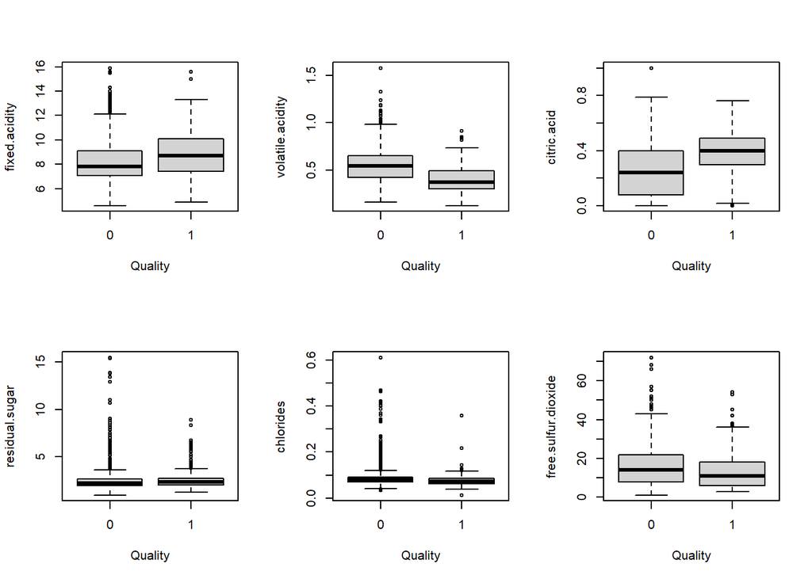

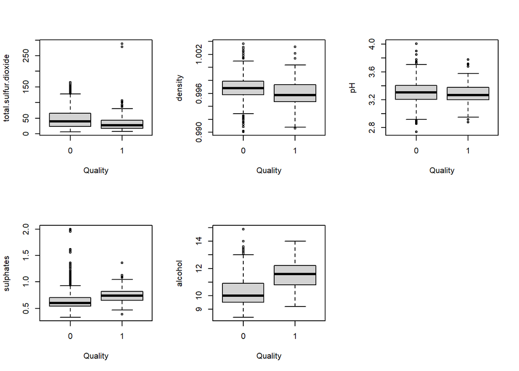

```r
par(mfrow=c(2,3))
for (v in 1:11) {
  boxplot(wine[,v]~Quality,data = wine,ylab = colnames(wine)[v] )
}
```

#Cross Validation for Classification For classification problems, cross validation works similar to how it is used in linear regression. Instead of using MSE, we use the number of misclassified observations to quantify test error.

Cross validation is a method that checks how well the model fits test data. It is used specifically when there is not a data set that is specifically used as test data. Cross Validation allows us to use portions of the training data as test data instead.

For this project, we need to test and build each method with the same training and test data sets. We will use k-fold cross validation with a k of 10. The code used to split the data can be found in the following section.

```r
#set the seed so we get the same groups each time
set.seed(1)

#this section of code uses the r package caret to create
#10 folds of the numbers from 1 to 1599. So if you do not have
#the caret package, you will need to install it.

flds <- createFolds(c(1:1599), k = 10, list = TRUE, returnTrain = FALSE)
names(flds)[1] <- "train"

#Once I created the folds of the numbers between 1 and 1599, I used these to
#pick the corresponding columns of the data frame. These can be used for
#all the following methods to calculate test error using the k-fold
#method of cross validation


fold1 <- winequality.red[flds$train,]
fold2 <- winequality.red[flds$Fold02,]
fold3 <- winequality.red[flds$Fold03,]
fold4 <- winequality.red[flds$Fold04,]
fold5 <- winequality.red[flds$Fold05,]
fold6 <- winequality.red[flds$Fold06,]
fold7 <- winequality.red[flds$Fold07,]
fold8 <- winequality.red[flds$Fold08,]
fold9 <- winequality.red[flds$Fold09,]
fold10 <- winequality.red[flds$Fold10,]
folds = list(fold1,fold2,fold3,fold4,fold5,fold6,fold7,fold8,fold9,fold10)
```

# QDA by Madison

In this section, we will use the Quadratic Discriminant Analysis classification method. We will be doing it with the resampling method of k-fold cross validation. Using a k = 10, we will fit the method 10 different times in order to get a test error.

```r
#We need to initialize the structures that we will use to store things
testerror = NULL
training = NULL
i = 1

#We need to use a loop to do the QDA analysis 10 times.
while(i <11){
  #this line selects the test fold
  testdata = folds[[i]]
  #this line puts the rest of the folds in a list of lists
  traindata = folds[-i]
  #this line changes the list of lists into a data frame
  training = dplyr::bind_rows(traindata)
  #this line fits the qda method to the data. Everything but the original
  #quality are used as responses. We are predicting the quality based on
  #the 0 and 1 method. It is also only fit on the training observations
  qda.fit = qda(Quality~. -quality, data=training)
  print(paste0("QDA model for Test Set ",i))
  print(qda.fit)
  cat("\n")
  cat("\n")
  #This line uses the built in predict function to figure out what
  #our model would predict for the test data.
  qda.predict = predict(qda.fit, testdata)$class
  #this line calculates the average misclassification rate of each iteration
  testerror[i]= mean(qda.predict != testdata$Quality)
  #this is the iterator so we can move through the loop
  i = i +1
}
```

```
## [1] "QDA model for Test Set 1"
## Call:
## qda(Quality ~ . - quality, data = training)
##
## Prior probabilities of groups:
##         0         1
## 0.8624044 0.1375956
##
## Group means:
##   fixed.acidity volatile.acidity citric.acid residual.sugar  chlorides
## 0      8.214907        0.5465028   0.2523691       2.509106 0.08892909
## 1      8.810101        0.4091414   0.3763131       2.680556 0.07639899
##   free.sulfur.dioxide total.sulfur.dioxide   density       pH sulphates
## 0            16.14263             48.37349 0.9968309 3.314464 0.6418131
## 1            13.95960             34.90404 0.9959963 3.286414 0.7433333
##    alcohol
## 0 10.25383
## 1 11.51338
##
##
## [1] "QDA model for Test Set 2"
## Call:
## qda(Quality ~ . - quality, data = training)
##
## Prior probabilities of groups:
##         0         1
## 0.8637943 0.1362057
##
## Group means:
##   fixed.acidity volatile.acidity citric.acid residual.sugar  chlorides
## 0      8.256879        0.5470153   0.2553097       2.517056 0.08922767
## 1      8.853571        0.4051020   0.3745918       2.715306 0.07501020
##   free.sulfur.dioxide total.sulfur.dioxide   density       pH sulphates
## 0            16.21158             48.24618 0.9968697 3.313926 0.6447627
## 1            14.29592             36.17857 0.9960224 3.290918 0.7417857
##    alcohol
## 0 10.25660
## 1 11.52866
##
##
```

[output cut: 143 more lines]

```
##
## Prior probabilities of groups:
##         0         1
## 0.8673611 0.1326389
##
## Group means:
##   fixed.acidity volatile.acidity citric.acid residual.sugar  chlorides
## 0      8.245476        0.5472498   0.2551161       2.506845 0.08940512
## 1      8.797382        0.4030628   0.3749215       2.695026 0.07578534
##   free.sulfur.dioxide total.sulfur.dioxide   density       pH sulphates
## 0            16.18975             48.54444 0.9968595 3.314556 0.6444516
## 1            14.44241             34.63351 0.9959486 3.288586 0.7411518
##    alcohol
## 0 10.25479
## 1 11.54276
```

```r
#this averages the test errors from the loop to find the overall test error
kfoldtesterror = mean(testerror)
print(paste0("Average error of the QDA method using 10-fold cross validation is "
             ,round(kfoldtesterror, digits = 4)))
```

```
## [1] "Average error of the QDA method using 10-fold cross validation is 0.1489"
```

#LDA by Chung Ho

```r
split <- data.frame(flds[1])
split <- as.vector(split[,1])
wine.test <- wine[split,]
wine.train <- wine[-split,]

# LDA using train data
wine.model <- lda(Quality~., data = wine.train)
wine.model
```

```
## Call:
## lda(Quality ~ ., data = wine.train)
##
## Prior probabilities of groups:
##         0         1
## 0.8624044 0.1375956
##
## Group means:
##   fixed.acidity volatile.acidity citric.acid residual.sugar  chlorides
## 0      8.214907        0.5465028   0.2523691       2.509106 0.08892909
## 1      8.810101        0.4091414   0.3763131       2.680556 0.07639899
##   free.sulfur.dioxide total.sulfur.dioxide   density       pH sulphates
## 0            16.14263             48.37349 0.9968309 3.314464 0.6418131
## 1            13.95960             34.90404 0.9959963 3.286414 0.7433333
##    alcohol
## 0 10.25383
## 1 11.51338
##
## Coefficients of linear discriminants:
##                                LD1
## fixed.acidity         1.790771e-01
## volatile.acidity     -1.008505e+00
## citric.acid           8.535069e-01
## residual.sugar        1.584990e-01
## chlorides            -5.109847e+00
## free.sulfur.dioxide  -1.924204e-03
## total.sulfur.dioxide -5.312991e-03
## density              -2.274737e+02
## pH                   -1.915074e-01
## sulphates             2.606402e+00
## alcohol               5.168647e-01
```

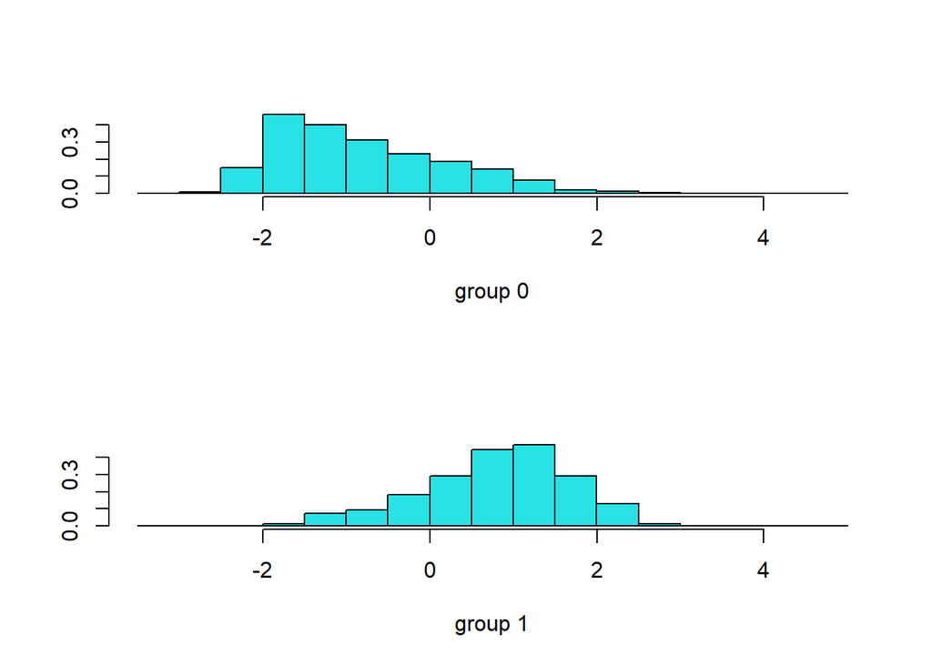

```r
lda.pred <- predict(wine.model, wine.test)
test.err.lda <- mean(lda.pred$class!=wine.test$Quality)

plot(wine.model)
```

```r
# Prediction using LDA model
wine.pred <- wine.model %>% predict(wine.test)
mean( wine.pred$class == wine.test$Quality )
```

```
## [1] 0.9125
```

#KNN - Mike

```r
#Use the same trainset from above in order to maintain consistency.
#Split the data into train and test to allow for kNN approach.
#Perform kNN model with k=39 because 39 is sqrt of 1599 (typical approach to use k=sqrt(n)).
errors = NULL
for (i in 1:10) {
  split <- data.frame(flds[i])
  split <- as.vector(split[,1])
  test <- wine[split,]
  train <- wine[-split,]
  wineTrain_Target <- train[,12]
  knn.pred1 <- knn(train,test,wineTrain_Target,k=39)
  #Compute test errors for all folds.
  errors[i] <- mean(knn.pred1 != test$Quality)
}

#Create a table to show actual vs predicted
table(knn.pred1,test$Quality)
```

```
##
## knn.pred1   0   1
##         0 133  26
##         1   0   0
```

```r
#Compute mean test error.
knn.test_error <- mean(errors)

#Perform kNN again, with k=5 this time.
errors2 = NULL
for (i in 1:10) {
  split <- data.frame(flds[i])
  split <- as.vector(split[,1])
  test <- wine[split,]
  train <- wine[-split,]
  wineTrain_Target <- train[,12]
  knn.pred2 <- knn(train,test,wineTrain_Target,k=5)
  #Compute errors across all folds.
  errors2[i] <- mean(knn.pred2 != test$Quality)
}

#Create a table to show actual vs predicted
table(knn.pred2,test$Quality)
```

```
##
## knn.pred2   0   1
##         0 128  17
##         1   5   9
```

```r
#Compute mean test error.
knn.test_error2 <- mean(errors2)

#Perform kNN with k=10
errors3 = NULL
for (i in 1:10) {
  split <- data.frame(flds[i])
  split <- as.vector(split[,1])
  test <- wine[split,]
  train <- wine[-split,]
  wineTrain_Target <- train[,12]
  knn.pred3 <- knn(train,test,wineTrain_Target,k=10)
  #Compute errors across folds.
  errors3[i] <- mean(knn.pred3 != test$Quality)
}

#Create a table to show actual vs predicted
table(knn.pred3,test$Quality)
```

```
##
## knn.pred3   0   1
##         0 129  23
##         1   4   3
```

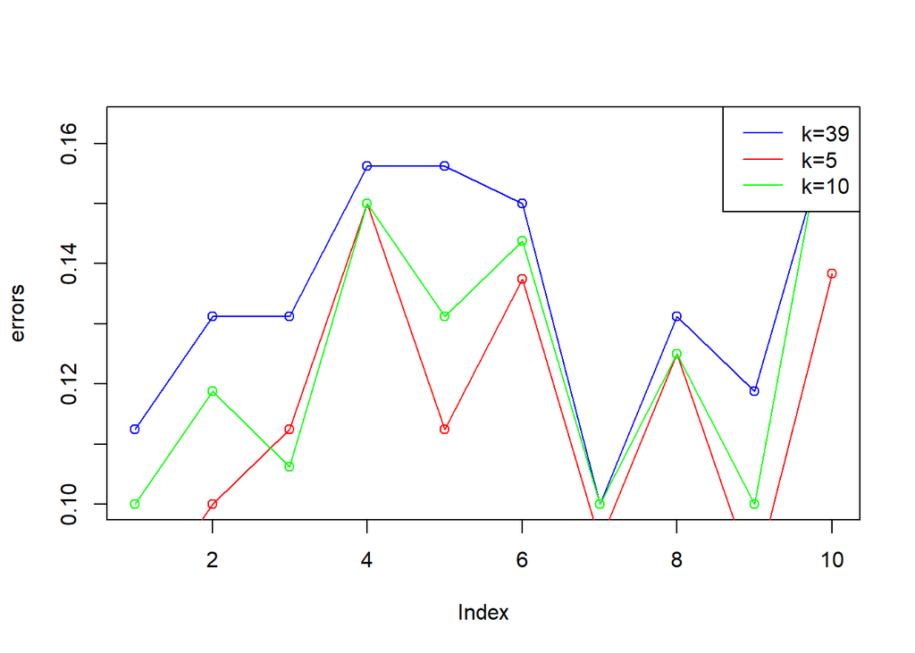

```r
#Compute mean test error.
knn.test_error3 <- mean(errors3)

#Plot the errors of each of the kNN models with different k values
plot(errors,col="blue")
lines(errors,col="blue")
points(errors2,col="red")
lines(errors2,col="red")
points(errors3,col="green")
lines(errors3,col="green")
legend("topright",legend=c("k=39","k=5","k=10"),lty=c(1,1),col=c("blue","red","green"))
```

#Random Forest - Shao-Wei

First of all, we randomly select one of testing and training set to check the scale of the forest. It shows that the curve is gradually being stable after 200 trees from the below plot. Thus, the number of trees is 200 for later steps.

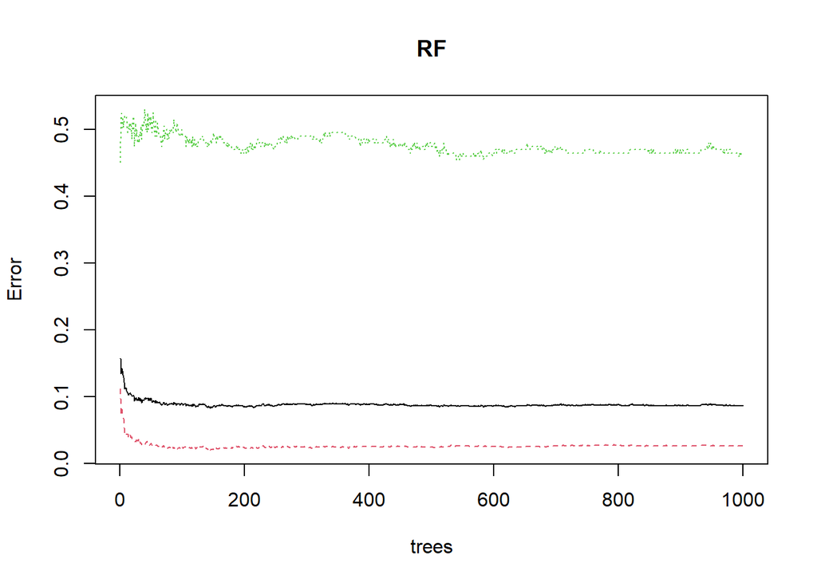

```r
  split<-data.frame(flds[1])
  split<-as.vector(split[,1])
  test<-wine[split,]
  y.test<-test[,12]
  x.test<- test[,1:11]
  train<-wine[-split,]
  RF<-randomForest(formula = Quality ~ ., data = train, xtest = x.test , ytest = y.test , ntree = 1000, mtry=round(sqrt(ncol(x.test))))
  plot(RF)
```

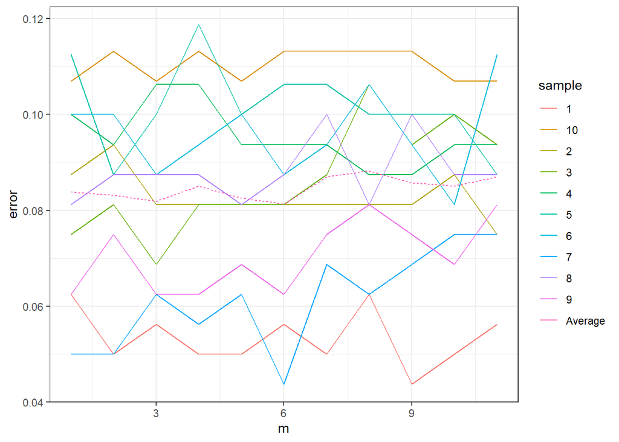

```r
same.data.rf.error<-data.frame(sample=rep(1:10,each=11),m=rep(1:11,times=10),error=NA)
for (i in 1:10) {
  split<-data.frame(flds[i])
  split<-as.vector(split[,1])
  test<-wine[split,]
  y.test<-test[,12]
  x.test<- test[,1:11]
  train<-wine[-split,]
  for (m in 1:11) {
      RF<-randomForest(formula = Quality ~ ., data = train, xtest = x.test , ytest = y.test , ntree = 200, mtry=m)
      same.data.rf.error[11*(i-1)+m,3]<-RF$test$err.rate[200,1]
  }
}

#mean comparisonin in different m

ave.rf.error<-data.frame(sample=rep("Average"),m=c(1:11),error=rep(NA,11))
for (i in 1:11) {
  ave.rf.error[i,3]<-mean(same.data.rf.error[same.data.rf.error$m==i,3])
}
rf.error<-rbind(same.data.rf.error,ave.rf.error)
rf.error$sample<-as.factor(rf.error$sample)
rf.error<-cbind(rf.error,average=c(rep(0,110),rep(1,11)))
ggplot(rf.error,aes(x=m , y = error,color=sample,linetype=as.factor(average))) +
  geom_line() + guides(linetype=FALSE) + theme_bw()
```

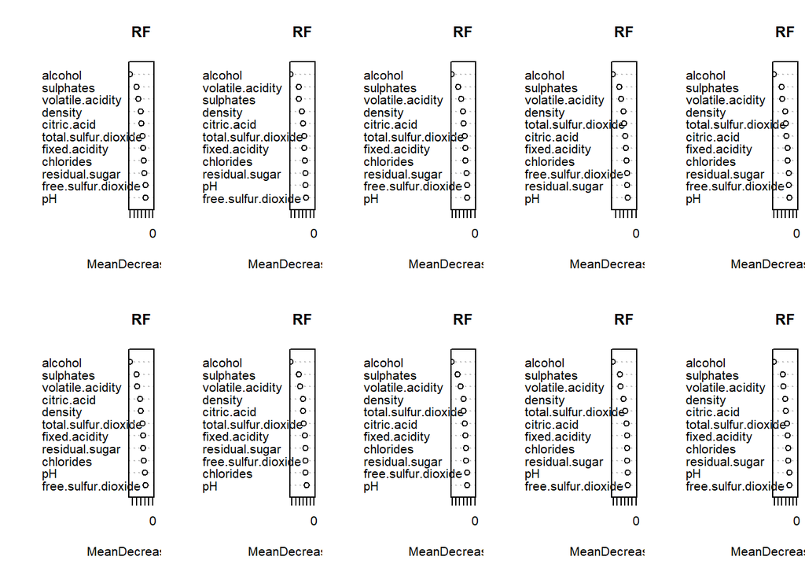

```r
###RF with m=4###
accu<-matrix(NA,10,1)
accu1<-matrix(NA,10,1)
quality.table<-array(NA,c(2,2,10),dimnames =list(c("test.0","test.1"),c("predi.0","predi.1"),c(1:10)) )

par(mfrow=c(2,5))
for (i in 1:10) {
  split<-data.frame(flds[i])
  split<-as.vector(split[,1])
  test<-wine[split,]
  y.test<-test[,12]
  x.test<- test[,1:11]
  train<-wine[-split,]
  RF<-randomForest(formula = Quality ~ ., data = train, xtest = x.test , ytest = y.test , ntree = 200, mtry=4)
  accu[i,]<-sum(test[,12]==RF$test$predicted)/length(test[,12]) #overall accuracy
  importance(RF)
  varImpPlot(RF, sort = TRUE)
}
```

```r
mean(accu)
```

```
## [1] 0.9211753
```

```r
for (i in 1:10) {
  split<-data.frame(flds[i])
  split<-as.vector(split[,1])
  test<-wine[split,]
  y.test<-test[,12]
  x.test<- test[,-c(9,12)]
  train<-wine[-split,]
  RF<-randomForest(formula = Quality ~ .-pH, data = train, xtest = x.test , ytest = y.test , ntree = 200, mtry=4)
  accu1[i,]<-sum(test[,12]==RF$test$predicted)/length(test[,12])
  #overall accuracy
  count<-table(test.set=test[,12],prediction=RF$test$predicted)
  for (r in 1:2) {
    for (c in 1:2) {
      quality.table[r,c,i]<-count[r,c]
    }

  }
}
mean(accu1)
```

```
## [1] 0.9180582
```

```r
quality.table
```

```
## , , 1
##
##        predi.0 predi.1
## test.0     139       2
## test.1       6      13
##
## , , 2
##
##        predi.0 predi.1
## test.0     137       2
## test.1      11      10
##
## , , 3
##
##        predi.0 predi.1
## test.0     134       5
## test.1       9      12
##
## , , 4
##
##        predi.0 predi.1
## test.0     131       3
## test.1      14      12
##
## , , 5
##
##        predi.0 predi.1
## test.0     129       7
## test.1      10      14
##
## , , 6
##
##        predi.0 predi.1
## test.0     134       2
## test.1      10      14
##
## , , 7
##
##        predi.0 predi.1
## test.0     140       4
## test.1       5      11
##
## , , 8
##
##        predi.0 predi.1
## test.0     136       3
## test.1      10      11
##
## , , 9
##
##        predi.0 predi.1
## test.0     138       3
## test.1       8      11
##
## , , 10
##
##        predi.0 predi.1
## test.0     127       6
## test.1      11      15
```